# Final Project Group 9

Nitin, Rachel, Annu

2022-12-03

# Package Overview

This R package contains functions that perform logistic regression using numerical methods on a user’s chosen response and predictor data. First inital weights for the optimising functrion are estimated and then coefficients($\beta$) which minimize the cost function are estimated which contains response and predictor data and the intercept. This is done using the function logreg_optim() with following cost function-
$$\hat{\beta}\::=\underset{\beta}{\operatorname{argmin}}\sum_{i=1}^{n}(-y_{i}\cdot\ln(p_{i})-(1-y_{i})\cdot\ln(1-p_{i}))$$
where
$$p_{i}\::=\frac{1}{1+exp(-x_{i}^{T}\beta)}$$
with $y_{i}$ representing the $i^{\text{th}}$ observation of the response and $x_{i}$ representing the $i^{\text{th}}$ row of the predictors.

## How to install

```r
#installing the package from github
library(devtools)
install_github("AU-R-Data-Science/Final-Project-group-9",force=TRUE)
```

[output not shown]

```r
library(LogReg)
```

## Let’s load data and see how it works

```r
data=read.csv("winequality-red.csv")
data$quality=ifelse(data$quality<6,1,0)
n_feat=ncol(data)

dt = sort(sample(nrow(data), nrow(data)*.7))
train<-data[dt,]

x=as.matrix(train[,1:n_feat-1])
y=train[,n_feat]
head(x)
```

```
##   fixed.acidity volatile.acidity citric.acid residual.sugar chlorides
## 1           7.4             0.70        0.00            1.9     0.076
## 2           7.8             0.88        0.00            2.6     0.098
## 3           7.8             0.76        0.04            2.3     0.092
## 6           7.4             0.66        0.00            1.8     0.075
## 8           7.3             0.65        0.00            1.2     0.065
## 9           7.8             0.58        0.02            2.0     0.073
##   free.sulfur.dioxide total.sulfur.dioxide density   pH sulphates alcohol
## 1                  11                   34  0.9978 3.51      0.56     9.4
## 2                  25                   67  0.9968 3.20      0.68     9.8
## 3                  15                   54  0.9970 3.26      0.65     9.8
## 6                  13                   40  0.9978 3.51      0.56     9.4
## 8                  15                   21  0.9946 3.39      0.47    10.0
## 9                   9                   18  0.9968 3.36      0.57     9.5
```

## Bootstrap Confidence intervals:

Below are the 95% and 90% confidence intervals for $\beta$ with 30 and 40 bootstraps respectively.

```r
#calling bootsrap function from package
library(boot)
bootstrapCI(x,y,alpha=0.05,n=30)
```

```
##                      Level      Lower     Upper
## intercept             0.95 0.09123385 0.5011587
## fixed.acidity         0.95 0.13375555 0.7908000
## volatile.acidity      0.95 0.11007454 0.5707667
## citric.acid           0.95 0.11137128 0.4908408
## residual.sugar        0.95 0.11403130 1.1163190
## chlorides             0.95 0.07607373 0.6429449
## free.sulfur.dioxide   0.95 0.02306254 0.3799434
## total.sulfur.dioxide  0.95 0.14744284 0.4890366
## density               0.95 0.17999568 0.7082105
## pH                    0.95 0.20438096 1.0413627
## sulphates             0.95 0.08483670 0.6538991
## alcohol               0.95 0.04360652 0.6411128
```

```r
bootstrapCI(x,y,alpha=0.1,n=40)
```

```
##                      Level      Lower     Upper
## intercept              0.9 0.14188457 0.8341359
## fixed.acidity          0.9 0.08454506 0.5414313
## volatile.acidity       0.9 0.14393897 0.5442754
## citric.acid            0.9 0.06542883 0.2822216
## residual.sugar         0.9 0.23387896 1.0707426
## chlorides              0.9 0.13620779 0.6078354
## free.sulfur.dioxide    0.9 0.07368215 0.5178205
## total.sulfur.dioxide   0.9 0.11407638 0.5314094
## density                0.9 0.09181590 0.4723714
## pH                     0.9 0.07008489 0.4753870
## sulphates              0.9 0.22407654 1.0048069
## alcohol                0.9 0.03500635 0.4062715
```

## Logistic Curve

Below is the logistic curve of 2nd column of x variables vs. the predicted probabilities.

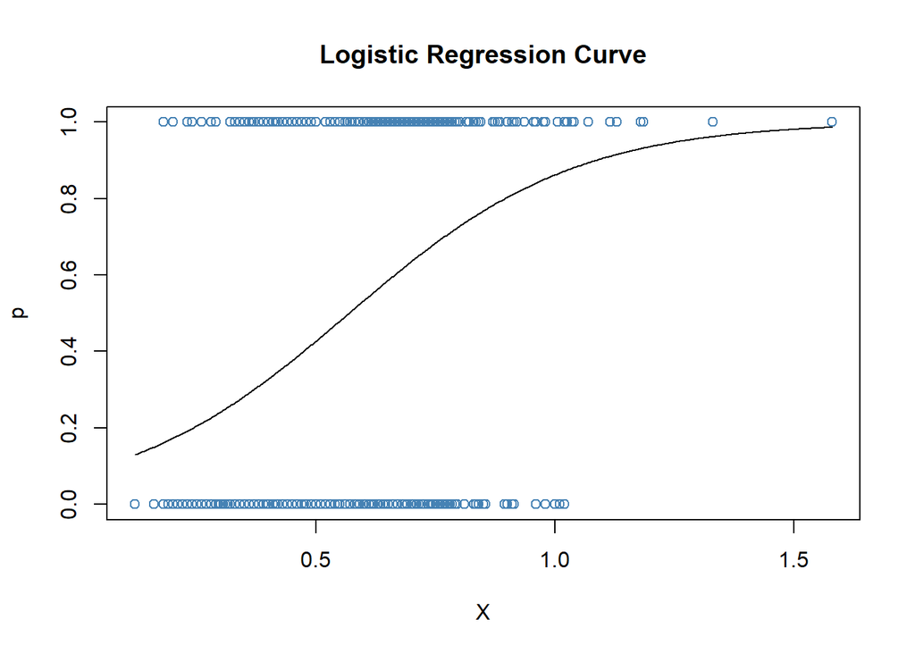

```r
#calling glm_plot function from package
glm_plot(x,y,2)
```

## The standard confusion matrix with cutoff 0.5.

4)The resulting ``Confusion Matrix’’ (see this link) using a cut-off value for prediction at 0.5 (i.e. assign value 1 for predictions above 0.5 and value 0 for prediction below or equal to 0.5). In addition, based on this cut-off value, also output the following metrics: * Prevalence * Accuracy * Sensitivity * Specificity * False Discovery Rate * Diagnostic Odds Ratio

```r
#calling suitable function from package
library(caret)
conf_matrix(x,y)
```

```
## [[1]]
##           Reference
## Prediction   0   1
##          0 470 161
##          1 133 355
##
## [[2]]
##            Prevalence              Accuracy           Sensitivity
##             0.5388740             0.7372654             0.7794362
##           Specificity  False Discovery Rate Diagnostic Odds Ratio
##             0.6879845             0.2551506             9.9163726
##                cutoff
##             0.5000000
```

## The user can also see how various metric varies with different cutoff values and optimize the model according ly to best fit the needs.

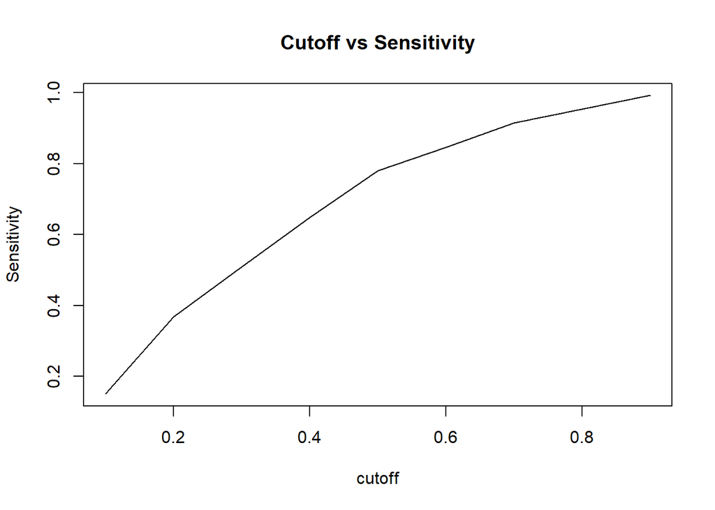

```r
#calling function from package
metricplot(x,y,"Sensitivity")
```

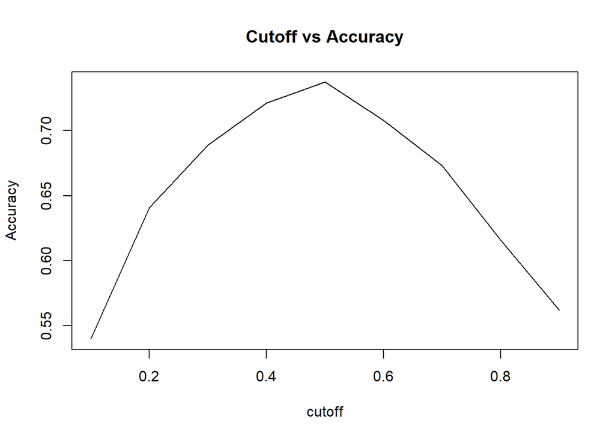

```r
metricplot(x,y,"Accuracy")
```

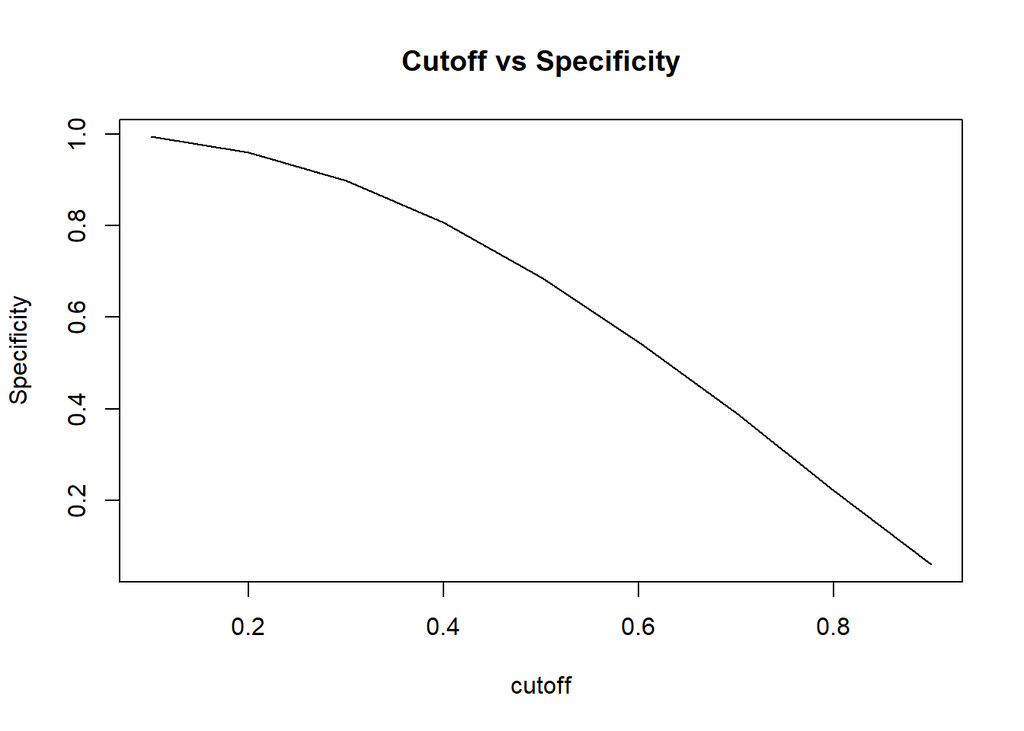

```r
metricplot(x,y,"Specificity")
```

## Help ducoments for all functions in package are generated simply by using “?function”

```r
#calling function from package
?metricplot
```

```
## starting httpd help server ... done
```